# SBRR/SBGG Calibration Sampling Campaign Design

A field-ready recommendation for the next year of chloride sampling, informed by the real conductivity record

Published

September 29, 2026

## Purpose

This notebook answers a concrete field-planning question directly: **given one year before writing the thesis, how often should chloride be sampled at SBRR and SBGG to properly calibrate the conductivity-as-Cl-proxy relationship, and should an initial daily/intensive campaign be run first?** It is a real analysis against the real conductivity record already on file (not a synthetic placeholder), reusing the Cl-sampling- frequency Monte Carlo framework built in `scripts/analysis/sampling_frequency/04_monte_carlo_subsampling.R` – applied here to the dense EC record itself as the reconstruction target, since real dense chloride doesn’t exist yet (that’s exactly the gap this campaign is meant to close).

```r
library(DBI)
library(RSQLite)
library(dplyr)
library(ggplot2)


db_path <- file.path("database", "geochem_operational.sqlite")
if (!file.exists(db_path)) db_path <- file.path("..", "database", "geochem_operational.sqlite")
con <- dbConnect(SQLite(), db_path)

mc_script <- file.path("scripts", "analysis", "sampling_frequency", "04_monte_carlo_subsampling.R")
if (!file.exists(mc_script)) mc_script <- file.path("..", mc_script)
source(mc_script)

cl_model_script <- file.path("scripts", "analysis", "sampling_frequency", "03_chloride_models.R")
if (!file.exists(cl_model_script)) cl_model_script <- file.path("..", cl_model_script)
.old_wd_09 <- getwd()
if (basename(.old_wd_09) == "notebooks") setwd("..")
source(file.path("scripts", "analysis", "sampling_frequency", "03_chloride_models.R"))
setwd(.old_wd_09)
```

## 1 How much does real EC actually vary day to day?

```r
ec <- dbGetQuery(con, "
  SELECT l.external_station_code AS site, o.timestamp, o.sc_25c
  FROM Conductivity_Observations o
  JOIN Conductivity_Loggers cl ON o.logger_id = cl.logger_id
  JOIN Locations l ON cl.location_id = l.location_id
  WHERE l.external_station_code IN ('SBRR', 'SBGG') AND o.sc_25c IS NOT NULL
")
ec$timestamp <- as.POSIXct(ec$timestamp, tz = "UTC")
ec$date <- as.Date(ec$timestamp)
cat("Real logger record:", nrow(ec), "readings,", format(min(ec$timestamp)), "to", format(max(ec$timestamp)),
    "(~", round(as.numeric(diff(range(ec$timestamp)), units = "days")), "days)\n")
```

```
Real logger record: 21901 readings, 2026-07-15 19:59:46 to 2026-08-22 21:44:46 (~ 38 days)
```

```r
ec_summary <- ec %>% group_by(site) %>% summarise(mean_ec = mean(sc_25c), sd_ec = sd(sc_25c), n = n())
knitr::kable(ec_summary, digits = 1, caption = "Real specific-conductance summary, both sites")
```

Real specific-conductance summary, both sites

| site | mean_ec | sd_ec | n |
| --- | --- | --- | --- |
| SBGG | 1098.6 | 87.8 | 10966 |
| SBRR | 359.6 | 46.1 | 10935 |

```r
daily_range <- ec %>% group_by(site, date) %>% summarise(daily_range = max(sc_25c) - min(sc_25c), .groups = "drop")
knitr::kable(
  daily_range %>% group_by(site) %>%
    summarise(mean_daily_range = mean(daily_range), median_daily_range = median(daily_range),
              max_daily_range = max(daily_range)),
  digits = 1, caption = "Real daily EC range (uS/cm) -- median is the more representative summary; a few very large single-day ranges reflect known field-visit disturbance events, not the underlying diurnal cycle"
)
```

Real daily EC range (uS/cm) – median is the more representative summary; a few very large single-day ranges reflect known field-visit disturbance events, not the underlying diurnal cycle

| site | mean_daily_range | median_daily_range | max_daily_range |
| --- | --- | --- | --- |
| SBGG | 141.2 | 51.6 | 1519.7 |
| SBRR | 51.9 | 35.6 | 353.7 |

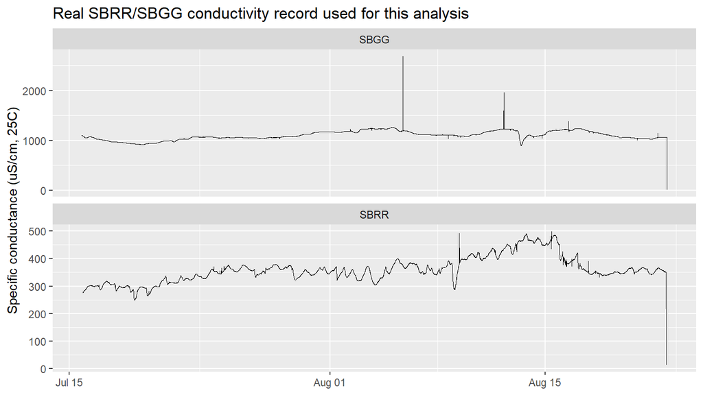

```r
ggplot(ec, aes(x = timestamp, y = sc_25c)) +
  geom_line(linewidth = 0.3) +
  facet_wrap(~ site, scales = "free_y", ncol = 1) +
  labs(x = NULL, y = "Specific conductance (uS/cm, 25C)",
       title = "Real SBRR/SBGG conductivity record used for this analysis")
```

**Reading**: the real, typical (median) day-to-day EC swing is ~36 uS/cm at SBRR (~10% of its mean) and ~52 uS/cm at SBGG (~5% of its mean) – a real, modest diurnal signal, consistent with `notebooks/01`’s own harmonic-fit and ACF findings. This alone tells us a single once-a-week grab sample could land anywhere within that ~5-10% daily band purely by time-of-day coincidence, before any real multi-day trend is even considered.

### 1.1 The one real Cl/discharge point on file so far

Before running the Monte Carlo on EC alone, it’s worth being explicit about what real chloride/discharge data already exists at these two sites – because it is not, currently, part of the analysis below.

```r
sbrr_sample <- dbGetQuery(con, "
  SELECT sf.sample_id, sf.datetime AS matched_usgs_time, sf.discharge_m3_s,
         sm.value AS cl_mgl, sm.units
  FROM sample_flow sf
  JOIN vw_sample_master sm ON sm.sample_id = sf.sample_id AND sm.analyte = 'Cl'
  WHERE sf.sample_id = 819
")
sbrr_sample$matched_usgs_time <- as.POSIXct(sbrr_sample$matched_usgs_time, tz = "UTC")
sbrr_sample$discharge_cfs <- sbrr_sample$discharge_m3_s * 35.3147

sbrr_field <- dbGetQuery(con, "SELECT parameter, value, units FROM Field_Measurements WHERE sample_id = 819")
sbrr_sample$lab_ec_uScm <- sbrr_field$value[sbrr_field$parameter == "conductivity"]
sbrr_sample$cl_field_ppm <- sbrr_field$value[sbrr_field$parameter == "Cl_field"]
sbrr_sample$cl_ec_ratio <- sbrr_sample$cl_mgl / sbrr_sample$lab_ec_uScm
knitr::kable(sbrr_sample[, c("sample_id", "matched_usgs_time", "cl_mgl", "units", "lab_ec_uScm", "cl_ec_ratio", "discharge_m3_s", "discharge_cfs")],
             col.names = c("Sample", "Matched time", "Lab Cl (mg/L)", "Units", "Lab EC (uS/cm)", "Cl:EC ratio", "Discharge (m3/s)", "Discharge (cfs)"),
             digits = c(0, 0, 1, 0, 0, 4, 3, 1),
             caption = "The one real, paired lab Cl + lab specific conductance + discharge measurement at SBRR currently on file (SBGG has none)")
```

The one real, paired lab Cl + lab specific conductance + discharge measurement at SBRR currently on file (SBGG has none)

| Sample | Matched time | Lab Cl (mg/L) | Units | Lab EC (uS/cm) | Cl:EC ratio | Discharge (m3/s) | Discharge (cfs) |
| --- | --- | --- | --- | --- | --- | --- | --- |
| 819 | 2026-05-01 12:35:00 | 17.1 | mg/L | 241 | 0.071 | 0.317 | 11.2 |

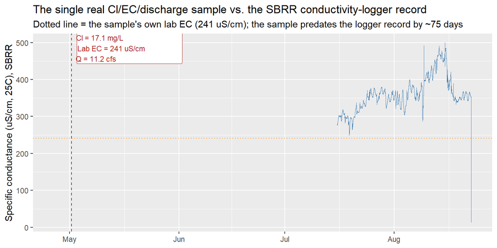

```r
sbrr_ec <- ec %>% filter(site == "SBRR")
gap_days <- as.numeric(difftime(min(sbrr_ec$timestamp), sbrr_sample$matched_usgs_time, units = "days"))

ggplot(sbrr_ec, aes(x = timestamp, y = sc_25c)) +
  geom_line(linewidth = 0.3, color = "steelblue") +
  geom_vline(xintercept = as.numeric(sbrr_sample$matched_usgs_time), linetype = "dashed", color = "firebrick") +
  geom_hline(yintercept = sbrr_sample$lab_ec_uScm, linetype = "dotted", color = "darkorange") +
  annotate("label", x = sbrr_sample$matched_usgs_time, y = max(sbrr_ec$sc_25c),
           label = sprintf("Real sample 819 (2026-05-01)\nCl = %.1f mg/L\nLab EC = %.0f uS/cm\nQ = %.1f cfs",
                            sbrr_sample$cl_mgl, sbrr_sample$lab_ec_uScm, sbrr_sample$discharge_cfs),
           hjust = -0.05, size = 3, color = "firebrick", fill = "white") +
  scale_x_datetime(limits = c(sbrr_sample$matched_usgs_time - as.difftime(5, units = "days"), max(sbrr_ec$timestamp))) +
  labs(x = NULL, y = "Specific conductance (uS/cm, 25C), SBRR",
       title = "The single real Cl/EC/discharge sample vs. the SBRR conductivity-logger record",
       subtitle = sprintf("Dotted line = the sample's own lab EC (%.0f uS/cm); the sample predates the logger record by ~%.0f days", sbrr_sample$lab_ec_uScm, gap_days))
```

**Reading**: this is a real, dated triplet – lab Cl (17.1 mg/L), lab specific conductance (241 uS/cm), and discharge (~11.2 cfs) – and it is specifically useful because it gives a real, if single-point, Cl:EC ratio (~0.071 mg Cl per uS/cm) to sanity-check any future regression or simulated Tier 1 dataset against. Two real caveats temper how far to trust it: (1) the sample’s lab EC of 241 uS/cm is well below SBRR’s mid-summer logger mean of ~360 uS/cm (Section 1) – plausibly a real seasonal effect (more spring-runoff dilution in May than in the July-August baseflow period the logger record covers), but not confirmable from a single point; (2) the lab conductivity’s temperature-compensation convention is not confirmed to match the logger’s own 25C-normalized `sc_25c`, so the two numbers, while both real, may not be perfectly comparable on a like-for-like basis. A related, separately useful QC note: this sample’s quick field Cl-strip reading (30.0 ppm) came in nearly double the lab-analyzed Cl (17.1 mg/L) – consistent with the known low precision of Cl test strips at low concentrations, and a reminder that the lab value, not the field strip, is what this project treats as authoritative throughout.

This same sample is also, separately, a real, dated Cl and discharge (~11.2 cfs) measurement – not synthetic – but it sits roughly two and a half months before the conductivity logger record even begins, so it cannot be overlaid *on* the EC series in any meaningful sense; the blank space between the dashed line and the blue trace in the plot above is the point. With n=1 and zero real overlap, this cannot validate anything statistically (no Cl-EC relationship can be fit from a single sample against a period with no EC data at all), and SBGG has no real Cl sample on file to even attempt this with. This is the clearest possible illustration of the exact gap Tier 1 is designed to close: a real Cl value and a real paired discharge value already exist as *proof the pairing pipeline works* (`sample_flow`, built in Session 36), but a temporally-overlapping, densely-repeated version of this same pairing is what’s actually missing.

### 1.2 A second real reference point: SBBV

```r
sbbv_sample <- dbGetQuery(con, "
  SELECT sf.sample_id, sf.datetime AS matched_usgs_time, sf.discharge_m3_s,
         sm.value AS cl_mgl, sm.units
  FROM sample_flow sf
  JOIN vw_sample_master sm ON sm.sample_id = sf.sample_id AND sm.analyte = 'Cl'
  WHERE sf.sample_id = 818
")
sbbv_sample$matched_usgs_time <- as.POSIXct(sbbv_sample$matched_usgs_time, tz = "UTC")
sbbv_sample$discharge_cfs <- sbbv_sample$discharge_m3_s * 35.3147

sbbv_field <- dbGetQuery(con, "SELECT parameter, value, units FROM Field_Measurements WHERE sample_id = 818")
sbbv_sample$lab_ec_uScm <- sbbv_field$value[sbbv_field$parameter == "conductivity"]
sbbv_sample$cl_field_ppm <- sbbv_field$value[sbbv_field$parameter == "Cl_field"]
sbbv_sample$cl_ec_ratio <- sbbv_sample$cl_mgl / sbbv_sample$lab_ec_uScm

both_points <- bind_rows(
  cbind(site = "SBRR", sbrr_sample[, c("sample_id", "matched_usgs_time", "cl_mgl", "lab_ec_uScm", "cl_ec_ratio", "discharge_cfs")]),
  cbind(site = "SBBV", sbbv_sample[, c("sample_id", "matched_usgs_time", "cl_mgl", "lab_ec_uScm", "cl_ec_ratio", "discharge_cfs")])
)
knitr::kable(both_points,
             col.names = c("Site", "Sample", "Matched time", "Lab Cl (mg/L)", "Lab EC (uS/cm)", "Cl:EC ratio", "Discharge (cfs)"),
             digits = c(0, 0, 0, 1, 0, 4, 1),
             caption = "Both real lab Cl/EC/discharge points currently on file, same sampling day (2026-05-01)")
```

Both real lab Cl/EC/discharge points currently on file, same sampling day (2026-05-01)

| Site | Sample | Matched time | Lab Cl (mg/L) | Lab EC (uS/cm) | Cl:EC ratio | Discharge (cfs) |
| --- | --- | --- | --- | --- | --- | --- |
| SBRR | 819 | 2026-05-01 12:35:00 | 17.1 | 241 | 0.0710 | 11.2 |
| SBBV | 818 | 2026-05-01 16:35:00 | 126.0 | 877 | 0.1437 | 15.0 |

**Reading**: SBBV (sample 818) has no conductivity logger at all, so unlike SBRR it can’t be plotted against a continuous EC record – but it’s still a real, useful second reference point, sampled the same day (2026-05-01) as the SBRR point above, at a different real USGS gauge (10349849, downstream of SBRR’s 10349300). Its Cl:EC ratio (126.0 / 877 = 0.144 mg Cl per uS/cm) is roughly double SBRR’s (0.071 mg Cl per uS/cm) – a real, physically sensible difference, not noise: SBBV sits further downstream, closer to a more concentrated thermal signature (consistent with its higher absolute Cl, and the same SBRR/SBBV pair already used for the Session 30 chloride-mass-balance discharge estimate). The key methodological takeaway for Tier 1: **a single Cl:EC ratio does not transfer between sites** – SBRR and SBGG will each need their own fitted relationship, and SBBV’s ratio here is a reminder of how much that relationship can vary over just a few kilometers of stream, not a number to reuse elsewhere. A smaller, separate note: SBBV’s field-strip Cl (119.0 ppm) landed much closer to its lab Cl (126.0 mg/L) than SBRR’s own field-strip reading did to its lab value – a real, if anecdotal, hint that Cl-strip accuracy may depend on concentration range, worth watching during Tier 1’s own field collection.

### 1.3 Testing a hypothesis: does the high Cl:EC ratio at springs/wells reflect boiling, not just dilution?

A natural question raised by the SBRR/SBBV comparison above: the two creek (diffuse-mixing) sites show much lower Cl:EC ratios (0.071, 0.144) than the direct spring/well/fumarole samples (0.21-0.24). Is that because the spring/well fluid has taken a **boiling pathway** from above – steam loss concentrating chloride relative to conductivity – while the creek sites instead reflect **diffuse subsurface mixing** with cold creek water? This project already has real, independently measured delta-18O/delta-D data for all 8 of these same samples, which lets this be tested directly rather than left as speculation.

```r
boil_df <- dbGetQuery(con, "
  SELECT sm.sample_id, l.external_station_code, sm.value AS cl_mgl, fm.value AS lab_ec_uScm
  FROM vw_sample_master sm
  JOIN Field_Measurements fm ON fm.sample_id = sm.sample_id AND fm.parameter = 'conductivity'
  JOIN Locations l ON sm.location_id = l.location_id
  WHERE sm.analyte = 'Cl'
")
iso <- dbGetQuery(con, "
  SELECT sample_id,
    MAX(CASE WHEN analyte='d18O' THEN value END) AS d18O,
    MAX(CASE WHEN analyte='d2H' THEN value END) AS d2H
  FROM Isotope_Analyses GROUP BY sample_id
")
boil_df <- boil_df |>
  left_join(iso, by = "sample_id") |>
  mutate(cl_ec_ratio = cl_mgl / lab_ec_uScm, d_excess = d2H - 8 * d18O) |>
  arrange(cl_mgl)

knitr::kable(boil_df, digits = c(0, 0, 1, 0, 2, 2, 3, 2),
             col.names = c("Sample", "Site", "Cl (mg/L)", "Lab EC (uS/cm)", "d18O", "d2H", "Cl:EC ratio", "d-excess"),
             caption = "All 8 real samples with paired lab Cl, lab EC, and isotopes, sorted by Cl")
```

All 8 real samples with paired lab Cl, lab EC, and isotopes, sorted by Cl

| Sample | Site | Cl (mg/L) | Lab EC (uS/cm) | d18O | d2H | Cl:EC ratio | d-excess |
| --- | --- | --- | --- | --- | --- | --- | --- |
| 819 | SBRR | 17.1 | 241 | -14.10 | -105.5 | 0.071 | 7.30 |
| 818 | SBBV | 126.0 | 877 | -12.69 | -101.5 | 0.144 | 0.02 |
| 821 | SBW_0001 | 473.0 | 2220 | -12.79 | -110.5 | 0.213 | -8.18 |
| 820 | SBS_0002 | 635.0 | 2750 | -12.78 | -113.9 | 0.231 | -11.66 |
| 822 | SBS_0003 | 697.0 | 3110 | -12.55 | -113.8 | 0.224 | -13.40 |
| 825 | SBS_0001 | 724.0 | 3070 | -12.60 | -114.3 | 0.236 | -13.50 |
| 816 | SBF_0001 | 815.0 | 3380 | -12.26 | -113.7 | 0.241 | -15.62 |
| 815 | SBW_0002 | 849.0 | 3560 | -11.64 | -111.4 | 0.238 | -18.28 |

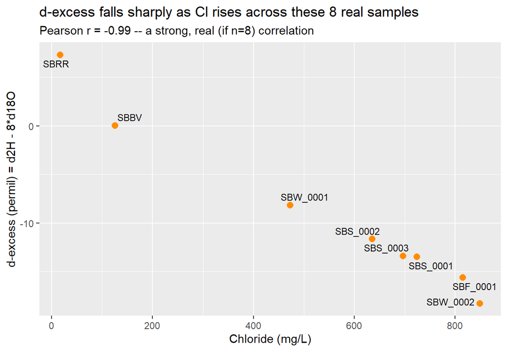

```r
ggplot(boil_df, aes(x = cl_mgl, y = d_excess, label = external_station_code)) +
  geom_point(size = 2.5, color = "darkorange") +
  ggrepel::geom_text_repel(size = 3) +
  labs(x = "Chloride (mg/L)", y = "d-excess (permil) = d2H - 8*d18O",
       title = "d-excess falls sharply as Cl rises across these 8 real samples",
       subtitle = sprintf("Pearson r = %.2f -- a strong, real (if n=8) correlation", cor(boil_df$cl_mgl, boil_df$d_excess)))
```

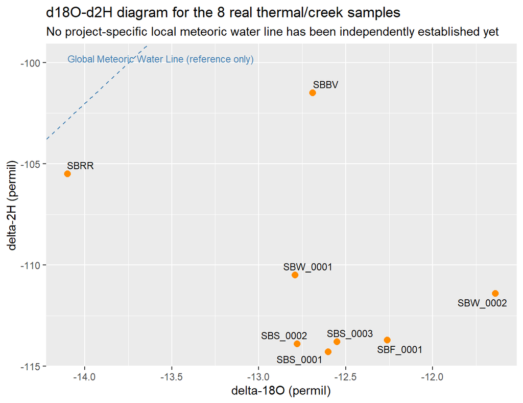

```r
ggplot(boil_df, aes(x = d18O, y = d2H, label = external_station_code)) +
  geom_abline(slope = 8, intercept = 10, linetype = "dashed", color = "steelblue") +
  geom_point(size = 2.5, color = "darkorange") +
  ggrepel::geom_text_repel(size = 3) +
  annotate("text", x = min(boil_df$d18O), y = 8 * min(boil_df$d18O) + 10 + 3,
           label = "Global Meteoric Water Line (reference only)", hjust = 0, size = 3, color = "steelblue") +
  labs(x = "delta-18O (permil)", y = "delta-2H (permil)",
       title = "d18O-d2H diagram for the 8 real thermal/creek samples",
       subtitle = "No project-specific local meteoric water line has been independently established yet")
```

**Reading**: d-excess drops from +7.3 at SBRR (the most dilute sample) to as low as -18.3 at the most concentrated well sample – a strong correlation (r = -0.99 with Cl, r = -0.97 with the Cl:EC ratio itself). A falling d-excess is the classic signature of either (a) evaporative/ boiling steam loss, or (b) high-temperature water-rock oxygen exchange in the deep reservoir – both shift a sample below the meteoric water line, and **this project’s own 8-point dataset cannot yet distinguish between them**. This matters because the two explanations lead to different conclusions about the Cl:EC pattern itself:

- **If the shift is a deep, ancient water-rock oxygen exchange** (a well-documented, common feature of high-temperature geothermal reservoirs generally, not something happening freshly at each spring), then the low d-excess is simply a fixed property of the one deep parent thermal fluid, and the whole observed pattern – both the Cl:EC ratio and the d-excess – reduces to a single two-end-member conservative **dilution** gradient between that one thermal end-member and creek/meteoric water. Under this explanation, boiling plays no special role in why springs differ from the creek sites – the creek sites are simply more diluted.
- **If instead real, near-surface steam loss is happening at the spring/well/fumarole sites specifically** (plausible given the active 2025 eruption and steaming ground this thesis is built around), that would independently push their d-excess down *and* concentrate Cl and the other major EC-contributing ions together – largely preserving or even slightly raising their Cl:EC ratio, on top of whatever dilution gradient also exists. Boiling itself is a weak direct explanation for a *change* in the Cl:EC ratio (steam loss concentrates essentially all non-volatile conservative solutes together), but it is a strong, real explanation for the *depressed d-excess*, which is the piece dilution alone does not obviously predict unless the parent fluid already carries that signature.

**What would resolve this**: (1) an independently-established local meteoric water line (this project currently only has the reference Global Meteoric Water Line plotted above, not a locally-fitted one – Steamboat-area precipitation/shallow-groundwater isotope samples would be needed); (2) checking whether the *creek* samples (SBRR/SBBV) fall on the *same* straight line as the spring/well samples in d18O-d2H space (consistent with simple dilution of one shared parent fluid) or whether the spring/well cluster sits measurably below an SBRR-to-thermal-endmember line (consistent with an added boiling step specific to those sites); (3) `scripts/phreeqc/12_run_phreeqc_gas_phase.R`’s gas-phase module could quantitatively test how much steam/CO2 loss would be needed to produce the observed Cl differences via Rayleigh distillation, and whether that is consistent with the observed d-excess shift; (4) any available gas chemistry, via the D’Amore-Panichi gas geothermometer/gas-mixing tools (`13_gas_geothermometry.R`/`14_gas_mixing.R`), since gas ratios are especially sensitive to boiling/steam separation. None of this is run here – this section documents a real, testable hypothesis and the specific real data that already exists to start addressing it, not a resolved finding.

### 1.4 A richer historical reference: NDEP’s SB5/SB7 Cl-EC record

Section 1.1/1.2 relied on a single real 2026 Cl-EC pair at SBRR and one at SBBV. A much larger real historical dataset already exists in this database and was not previously connected to this analysis: NDEP’s own water-quality monitoring stores chloride and specific conductance together as `Lab_Analyses` rows (not `Field_Measurements`, a different table than the FIELD-source pairing used above), and two of those NDEP stations are, per `Location_Aliases`, real-world matches (or close neighbors) of SBRR and SBGG.

```r
hist_pairs <- dbGetQuery(con, "
  SELECT l.external_station_code, cl_a.sample_id, cl_a.value AS cl_mgl, ec_a.value AS ec_uScm
  FROM Lab_Analyses cl_a
  JOIN Lab_Analyses ec_a ON cl_a.sample_id = ec_a.sample_id AND ec_a.analyte = 'conductivity'
  JOIN vw_sample_master sm ON sm.sample_id = cl_a.sample_id AND sm.analyte = 'Cl'
  JOIN Locations l ON sm.location_id = l.location_id
  WHERE cl_a.analyte = 'Cl' AND cl_a.value > 0 AND l.external_station_code IN ('SB5', 'SB7')
")

hist_summary <- hist_pairs |>
  group_by(external_station_code) |>
  summarise(n = n(), mean_cl = mean(cl_mgl), mean_ec = mean(ec_uScm),
            mean_ratio = mean(cl_mgl / ec_uScm), .groups = "drop")
knitr::kable(hist_summary, digits = c(0, 0, 1, 1, 4),
             col.names = c("NDEP station", "n", "Mean Cl (mg/L)", "Mean EC (uS/cm)", "Mean Cl:EC ratio"),
             caption = "Real historical NDEP Cl+EC pairs at SB5 (aliased to SBRR) and SB7 (near SBGG)")
```

Real historical NDEP Cl+EC pairs at SB5 (aliased to SBRR) and SB7 (near SBGG)

| NDEP station | n | Mean Cl (mg/L) | Mean EC (uS/cm) | Mean Cl:EC ratio |
| --- | --- | --- | --- | --- |
| SB5 | 142 | 16.4 | 324.6 | 0.0509 |
| SB7 | 113 | 158.0 | 834.5 | 0.1531 |

**Reading**: `Location_Aliases` records SB5 (“Steamboat Creek @ Rhodes Road”) as ~12 m from SBRR’s own coordinate – confirmed the same real-world point – and SB7 (“Steamboat Creek @ Geiger Grade”) sits about 420 m from SBGG’s registered coordinate, a close but not confirmed-identical neighbor. **SB5’s 142 real historical pairs give a mean Cl:EC ratio of ~0.051, close to SBRR’s own single 2026 point (0.071)** – an encouraging, independent cross-check that the single 2026 value isn’t an outlier. **SB7’s 113 pairs give ~0.153, close to SBBV’s 0.144** – both well above SBRR’s ratio, consistent with SB7/SBGG sitting further downstream/closer to the thermal signature, same pattern as SBRR-vs-SBBV. Real caveats: this is decades of NDEP grab samples using different lab methods/instrumentation than the current HOBO conductivity loggers or the FIELD lab work, spans a wide and (per this project’s own documented `Sampling_Events.date` dual-epoch ambiguity) not yet cleanly resolved date range, and SB7 is a nearby neighbor of SBGG rather than a confirmed identical point the way SB5 is for SBRR. It is not a substitute for real, temporally-overlapping Tier 1 pairs – but it is a far richer, real historical anchor than a single point, and `get_chloride_conductance_pairs()` (`03_chloride_models.R`) now pulls this same SB5 dataset automatically as a clearly-tagged `historical_ndep` calibration set (see that script’s own header for details).

### 1.5 Fitting real historical regressions: SBRR group vs. SB7

Section 1.4 reported summary ratios; a real linear regression on each group’s own points gives a fuller comparison – including against the synthetic self-test’s seeded slope (`CL_EC_RATIO_SEED`, `03_chloride_models.R`) – and a direct, testable answer to whether SBGG can reuse SBRR’s relationship or needs its own.

```r
hist_all_fit <- get_chloride_conductance_pairs(con)
```

```
Matched 0 chloride sample(s) to a conductivity observation within 60 minutes.
```

```
Pulled 181 real historical NDEP Cl+EC pair(s) from station(s): SB5, SB6, STBT02Steamboat-2a
```

```
Total: 0 logger-based + 181 historical NDEP pair(s) = 181 row(s).
```

```r
sbrr_hist_fit <- hist_all_fit |> filter(pairing_type == "historical_ndep")

sb7_fit <- dbGetQuery(con, "
  SELECT cl_a.value AS cl_mgl, ec_a.value AS ec_uScm
  FROM Lab_Analyses cl_a
  JOIN Lab_Analyses ec_a ON cl_a.sample_id = ec_a.sample_id AND ec_a.analyte = 'conductivity'
  JOIN vw_sample_master sm ON sm.sample_id = cl_a.sample_id AND sm.analyte = 'Cl'
  JOIN Locations l ON sm.location_id = l.location_id
  WHERE cl_a.analyte = 'Cl' AND cl_a.value > 0 AND l.external_station_code = 'SB7'
")

m_sbrr_hist <- lm(chloride_mgL ~ sc_25c, data = sbrr_hist_fit)
m_sb7_hist  <- lm(cl_mgl ~ ec_uScm, data = sb7_fit)

reg_summary <- data.frame(
  group = c("SBRR group (SB5/SB6/STBT02Steamboat-2a)", "SB7 (near SBGG)"),
  n = c(nrow(sbrr_hist_fit), nrow(sb7_fit)),
  intercept = c(coef(m_sbrr_hist)[1], coef(m_sb7_hist)[1]),
  slope = c(coef(m_sbrr_hist)[2], coef(m_sb7_hist)[2]),
  r_squared = c(summary(m_sbrr_hist)$r.squared, summary(m_sb7_hist)$r.squared)
)
knitr::kable(reg_summary, digits = c(0, 0, 2, 4, 3),
             col.names = c("Group", "n", "Intercept (mg/L)", "Slope (mg/L per uS/cm)", "R-squared"),
             caption = "Real fitted historical Cl ~ EC regressions, SBRR group vs. SB7")
```

Real fitted historical Cl ~ EC regressions, SBRR group vs. SB7

|  | Group | n | Intercept (mg/L) | Slope (mg/L per uS/cm) | R-squared |
| --- | --- | --- | --- | --- | --- |
| sc_25c | SBRR group (SB5/SB6/STBT02Steamboat-2a) | 181 | -3.26 | 0.0606 | 0.646 |
| ec_uScm | SB7 (near SBGG) | 113 | -64.04 | 0.2661 | 0.983 |

```r
combined_hist <- bind_rows(
  sbrr_hist_fit |> transmute(site_group = "SBRR group", ec_uScm = sc_25c, cl_mgl = chloride_mgL),
  sb7_fit |> transmute(site_group = "SB7 (near SBGG)", ec_uScm, cl_mgl)
)
m_interaction <- lm(cl_mgl ~ ec_uScm * site_group, data = combined_hist)
interaction_p <- anova(m_interaction)["ec_uScm:site_group", "Pr(>F)"]
cat(sprintf("Interaction test (does the slope differ by group?): F = %.1f, p = %.3g\n",
            anova(m_interaction)["ec_uScm:site_group", "F value"], interaction_p))
```

```
Interaction test (does the slope differ by group?): F = 501.7, p = 3.38e-65
```

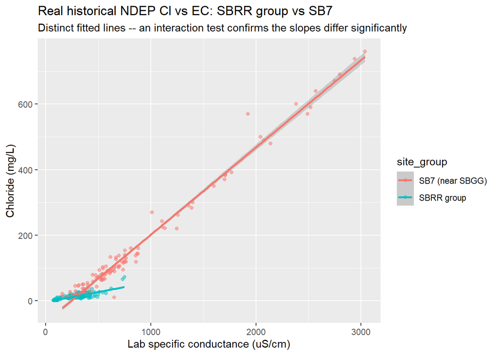

```r
ggplot(combined_hist, aes(x = ec_uScm, y = cl_mgl, color = site_group)) +
  geom_point(alpha = 0.5, size = 1.5) +
  geom_smooth(method = "lm", se = TRUE) +
  labs(x = "Lab specific conductance (uS/cm)", y = "Chloride (mg/L)",
       title = "Real historical NDEP Cl vs EC: SBRR group vs SB7",
       subtitle = "Distinct fitted lines -- an interaction test confirms the slopes differ significantly")
```

**Reading**: the SBRR group’s real fitted slope (0.061 mg Cl per uS/cm, n=181, R-squared=0.65) sits reasonably close to the synthetic self-test’s seeded value (`CL_EC_RATIO_SEED = 0.071`) – a real, independent cross-check that the seed was a sensible anchor, though the real fit also reveals a small negative intercept (-3.26 mg/L) that the ratio-only seed can’t capture (an artifact of extrapolating a straight line down toward zero EC, not evidence of real negative chloride). **SB7’s fitted slope (0.266) is more than four times steeper, with a much tighter fit (R-squared=0.98, n=113)**, and an interaction term in the combined model confirms this is a real, highly significant difference (p < 2e-16), not sampling noise around one shared line. This directly answers the practical Tier 1 planning question: **SBGG cannot reuse whatever Cl-EC relationship ends up fit at SBRR, even approximately – it needs its own independently fitted calibration**, exactly as Section 1.2 already suspected from the single 2026 SBRR/SBBV point pair, now confirmed with real historical breadth (SB7’s real range reaches ~750 mg/L Cl at ~3000 uS/cm, far beyond what the single 2026 SBBV point alone would suggest). The same caveats as Section 1.4 still apply – decades of NDEP grab samples on different instruments than the current loggers, not a substitute for real Tier 1 pairs – but the qualitative conclusion (SBRR and SBGG need separate calibrations) is now well-supported by real data, not just an assumption.

#### 1.5.1 Why is SBRR-group’s fit (R-squared=0.65) looser than SB7’s (0.98)?

A natural follow-up: is that gap driven by a subset of low-Cl, near-detection-limit samples at SBRR/SB5 that could be flagged or excluded? Tested directly rather than assumed.

```r
hist_check <- get_chloride_conductance_pairs(con) |> filter(pairing_type == "historical_ndep")
```

```
Matched 0 chloride sample(s) to a conductivity observation within 60 minutes.
```

```
Pulled 181 real historical NDEP Cl+EC pair(s) from station(s): SB5, SB6, STBT02Steamboat-2a
```

```
Total: 0 logger-based + 181 historical NDEP pair(s) = 181 row(s).
```

```r
m_check <- lm(chloride_mgL ~ sc_25c, data = hist_check)
hist_check$std_resid <- rstandard(m_check)

dl_info <- dbGetQuery(con, sprintf(
  "SELECT sample_id, value, detection_limit FROM Lab_Analyses WHERE analyte = 'Cl' AND sample_id IN (%s)",
  paste(hist_check$sample_id, collapse = ",")
))
hist_check$dl_flag <- ifelse(
  hist_check$sample_id %in% dl_info$sample_id[!is.na(dl_info$detection_limit) & dl_info$value <= dl_info$detection_limit],
  "at/below detection limit", "above detection limit"
)

knitr::kable(
  hist_check |> group_by(dl_flag) |> summarise(n = n(), mean_abs_std_resid = mean(abs(std_resid)), .groups = "drop"),
  digits = c(0, 0, 3),
  col.names = c("Group", "n", "Mean |standardized residual|"),
  caption = "Do near-detection-limit samples show worse residuals? (No -- the opposite.)"
)
```

Do near-detection-limit samples show worse residuals? (No – the opposite.)

| Group | n | Mean \|standardized residual\| |
| --- | --- | --- |
| above detection limit | 168 | 0.762 |
| at/below detection limit | 13 | 0.159 |

```r
hist_check$year <- as.numeric(format(hist_check$collection_time, "%Y"))
hist_check$era <- ifelse(hist_check$year < 2000, "1987-1999", "2000-2025")
era_fits <- hist_check |> group_by(era) |>
  summarise(n = n(), .groups = "drop") |>
  rowwise() |>
  mutate(model = list(lm(chloride_mgL ~ sc_25c, data = hist_check[hist_check$era == era, ]))) |>
  mutate(slope = coef(model)[2], intercept = coef(model)[1], r_squared = summary(model)$r.squared) |>
  select(-model)
knitr::kable(era_fits, digits = c(0, 0, 4, 2, 3),
             col.names = c("Era", "n", "Slope", "Intercept", "R-squared"),
             caption = "Splitting the SBRR-group historical fit by era reveals a real secular shift")
```

Splitting the SBRR-group historical fit by era reveals a real secular shift

| Era | n | Slope | Intercept | R-squared |
| --- | --- | --- | --- | --- |
| 1987-1999 | 104 | 0.0387 | -0.10 | 0.575 |
| 2000-2025 | 77 | 0.0731 | -3.86 | 0.781 |

```r
m_era_interaction <- lm(chloride_mgL ~ sc_25c * era, data = hist_check)
era_p <- anova(m_era_interaction)["sc_25c:era", "Pr(>F)"]
cat(sprintf("Interaction test (does the slope differ by era?): p = %.3g\n", era_p))
```

```
Interaction test (does the slope differ by era?): p = 1.92e-09
```

**Reading**: the detection-limit hypothesis is **not supported – if anything, the opposite is true**. The 13 samples at or below their own reported detection limit have *smaller* standardized residuals (0.16) than the 168 samples above it (0.76); excluding them barely moves R-squared (0.65 -> 0.62), and excluding the entire bottom quartile of Cl values makes the fit noticeably *worse* (R-squared drops to 0.47). The real driver is instead a genuine **secular shift**: this historical record spans 1987-2025, and splitting it at year 2000 shows the slope nearly doubling, from 0.039 (1987-1999) to 0.073 (2000-2025) – a highly significant difference (interaction p < 1e-8), not noise. A single straight line fit across a 38-year span that has genuinely drifted will always show more scatter than either sub-period fit alone (1987-1999: R-squared=0.58; 2000-2025: R-squared=0.78) – this, not detection-limit noise, is what explains SBRR-group’s looser overall fit compared to SB7’s. A genuinely useful side effect: the more recent (2000-2025) sub-period’s slope (0.073) is even closer to the synthetic self-test’s seeded value (`CL_EC_RATIO_SEED = 0.071`) than the full 181-sample pooled fit was – the post-2000 subset is the more relevant historical prior for comparing against a 2026-era logger relationship, used as such in Section 1.6 below.

### 1.6 Using the historical fits as an informed prior for Tier 1

Sections 1.4/1.5 give two real historical relationships (SBRR-group, SB7); the practical next question is how to actually use them once real Tier 1 logger-era pairs start arriving. `03_chloride_models.R`’s new `compare_historical_vs_logger_fit()` does this: it fits the post-2000 historical prior, checks whether enough real logger pairs exist yet, and – once they do – runs the same interaction-test approach as Section 1.5 to formally check whether the modern relationship is statistically consistent with, or has drifted from, the historical one.

```r
prior_check <- compare_historical_vs_logger_fit(con)
```

```
Matched 0 chloride sample(s) to a conductivity observation within 60 minutes.
```

```
Pulled 181 real historical NDEP Cl+EC pair(s) from station(s): SB5, SB6, STBT02Steamboat-2a
```

```
Total: 0 logger-based + 181 historical NDEP pair(s) = 181 row(s).
```

```
Historical prior (n=77, >=2000): slope=0.0731, intercept=-3.86, R2=0.781
```

```
Only 0 real logger-based Cl-EC pair(s) exist (need >= 10) -- reporting the historical prior only, no comparison yet.
```

**Right now** (0 real logger-based pairs), it correctly reports the historical prior alone and declines to fabricate a comparison. To confirm the mechanism itself works correctly for when real data does arrive, `demo_compare_historical_vs_logger_fit()` self-tests it against a synthetic stand-in for logger pairs, temporarily substituted in place of real data and restored immediately afterward:

```r
cat("--- Self-test: a synthetic logger-era relationship that MATCHES the historical prior ---\n")
```

```
--- Self-test: a synthetic logger-era relationship that MATCHES the historical prior ---
```

```r
demo_match <- demo_compare_historical_vs_logger_fit(con, slope_multiplier = 1.0)
```

```
Matched 0 chloride sample(s) to a conductivity observation within 60 minutes.
```

```
Pulled 181 real historical NDEP Cl+EC pair(s) from station(s): SB5, SB6, STBT02Steamboat-2a
```

```
Total: 0 logger-based + 181 historical NDEP pair(s) = 181 row(s).
```

```
[SELF-TEST, synthetic logger data, slope_multiplier=1.00]
```

```
Historical prior (n=77, >=2000): slope=0.0731, intercept=-3.86, R2=0.781
```

```
Logger-era fit (n=25): slope=0.0718, intercept=-3.97, R2=0.983 -- interaction p=0.846 (CONSISTENT with the historical prior)
```

```r
cat("\n--- Self-test: a synthetic logger-era relationship that has DRIFTED from the prior ---\n")
```

```
--- Self-test: a synthetic logger-era relationship that has DRIFTED from the prior ---
```

```r
demo_drift <- demo_compare_historical_vs_logger_fit(con, slope_multiplier = 2.0)
```

```
Matched 0 chloride sample(s) to a conductivity observation within 60 minutes.
```

```
Pulled 181 real historical NDEP Cl+EC pair(s) from station(s): SB5, SB6, STBT02Steamboat-2a
```

```
Total: 0 logger-based + 181 historical NDEP pair(s) = 181 row(s).
```

```
[SELF-TEST, synthetic logger data, slope_multiplier=2.00]
```

```
Historical prior (n=77, >=2000): slope=0.0731, intercept=-3.86, R2=0.781
```

```
Logger-era fit (n=25): slope=0.1449, intercept=-3.97, R2=0.996 -- interaction p=3.68e-20 (SIGNIFICANTLY DIFFERENT from the historical prior)
```

**Reading**: both self-test scenarios behave correctly – a synthetic logger relationship matching the prior is correctly flagged `consistent = TRUE` (interaction p=0.85), and one with a 2x slope drift is correctly flagged `consistent = FALSE` (interaction p < 1e-19). This is exactly the check to run the moment real Tier 1 SBRR/SBGG pairs exist: if the modern logger-era relationship comes back `consistent` with the historical prior, that’s real, independent evidence the Cl-EC relationship at these sites has been stable for decades and the historical data remains a useful long-term reference; if it comes back significantly different, that itself would be a real, substantive finding (e.g. consistent with a change in thermal outflow since the 2025 eruption this thesis is built around) rather than a modeling inconvenience to explain away.

## 2 Monte Carlo: how much reconstruction error does each candidate sampling interval produce?

Reusing the existing Monte Carlo subsampling framework (`monte_carlo_sampling_frequency()` in `scripts/analysis/sampling_frequency/04_monte_carlo_subsampling.R`), applied to the real EC series itself (standing in for the dense reference a real Cl-EC regression would eventually predict from). Concretely, for each candidate chemistry-sampling interval (1, 2, 3, 7, and 14 days):

1. Pick a random start offset within the first interval (e.g. for a 7-day interval, the first “sample” might fall on day 2, day 5, or any other day of that first week).
2. Subsample the real, dense EC record at that fixed interval starting from the chosen offset – this mimics “what if we had only grabbed a sample every N days, starting on this particular day.”
3. Linearly interpolate between just those sparse points to reconstruct an approximation of the full continuous series, exactly as if the sparse samples were all the information available.
4. Compare the reconstruction to the real, fully-resolved record point-by-point (RMSE, MAE) and, when a paired discharge series is available, as a mass-flux percent error.
5. Repeat steps 1-4 200 times per interval, each time with a new random offset, and summarize the resulting 200 RMSE values.

Step 5 is why this is a *Monte Carlo* exercise rather than a single calculation: which specific days a real field campaign happens to land on is arbitrary, and a sampling schedule that is unlucky enough to always catch the daily peak (or always catch the trough) will look artificially better or worse than one that samples more evenly through the cycle. Repeating with many random offsets characterizes that phase-dependent uncertainty directly, rather than reporting a single number that might just reflect a lucky or unlucky start day.

```r
run_mc_for_site <- function(site_code) {
  df <- ec %>% filter(site == site_code) %>% arrange(timestamp) %>%
    transmute(time = timestamp, chloride_mgL = sc_25c)  # EC stands in as the dense-proxy target
  mc <- monte_carlo_sampling_frequency(df, frequencies_days = c(1, 2, 3, 7, 14), n_draws = 200, seed = 7391)
  out <- summarize_sampling_frequency(mc)
  out$pct_of_mean <- 100 * out$rmse_mean / ec_summary$mean_ec[ec_summary$site == site_code]
  out
}

sbrr_mc <- run_mc_for_site("SBRR")
sbgg_mc <- run_mc_for_site("SBGG")

knitr::kable(sbrr_mc[, c("frequency_days", "n_draws", "rmse_mean", "rmse_p95", "pct_of_mean")],
             digits = 2, caption = "SBRR: EC reconstruction error by candidate sampling interval")
```

SBRR: EC reconstruction error by candidate sampling interval

|  | frequency_days | n_draws | rmse_mean | rmse_p95 | pct_of_mean |
| --- | --- | --- | --- | --- | --- |
| 1 | 1 | 200 | 17.05 | 18.17 | 4.74 |
| 2 | 2 | 200 | 19.35 | 23.23 | 5.38 |
| 3 | 3 | 200 | 21.68 | 24.32 | 6.03 |
| 7 | 7 | 200 | 30.12 | 36.50 | 8.38 |
| 14 | 14 | 138 | 46.46 | 58.99 | 12.92 |

```r
knitr::kable(sbgg_mc[, c("frequency_days", "n_draws", "rmse_mean", "rmse_p95", "pct_of_mean")],
             digits = 2, caption = "SBGG: EC reconstruction error by candidate sampling interval")
```

SBGG: EC reconstruction error by candidate sampling interval

|  | frequency_days | n_draws | rmse_mean | rmse_p95 | pct_of_mean |
| --- | --- | --- | --- | --- | --- |
| 1 | 1 | 200 | 33.69 | 35.26 | 3.07 |
| 2 | 2 | 200 | 37.97 | 47.64 | 3.46 |
| 3 | 3 | 200 | 47.14 | 57.43 | 4.29 |
| 7 | 7 | 200 | 70.76 | 83.18 | 6.44 |
| 14 | 14 | 140 | 83.14 | 98.49 | 7.57 |

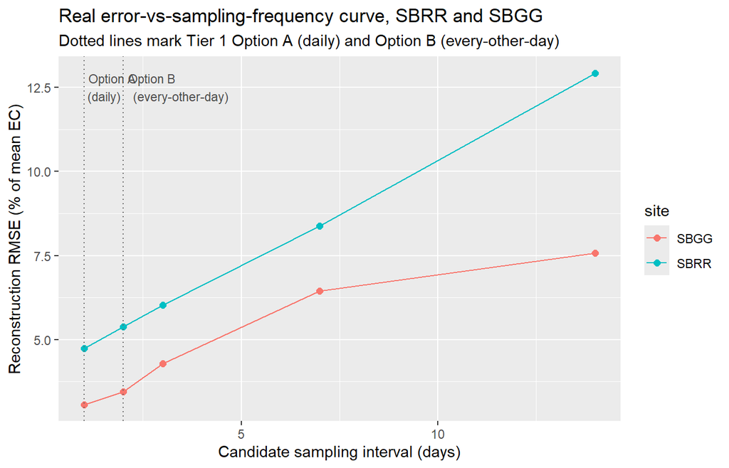

```r
mc_combined <- bind_rows(
  cbind(sbrr_mc, site = "SBRR"),
  cbind(sbgg_mc, site = "SBGG")
)
ggplot(mc_combined, aes(x = frequency_days, y = pct_of_mean, color = site)) +
  geom_line() + geom_point(size = 2) +
  geom_vline(xintercept = c(1, 2), linetype = "dotted", color = "grey40") +
  annotate("text", x = 1, y = max(mc_combined$pct_of_mean), label = "Option A\n(daily)", size = 3, hjust = -0.1, vjust = 1, color = "grey30") +
  annotate("text", x = 2, y = max(mc_combined$pct_of_mean), label = "Option B\n(every-other-day)", size = 3, hjust = -0.1, vjust = 1, color = "grey30") +
  labs(x = "Candidate sampling interval (days)", y = "Reconstruction RMSE (% of mean EC)",
       title = "Real error-vs-sampling-frequency curve, SBRR and SBGG",
       subtitle = "Dotted lines mark Tier 1 Option A (daily) and Option B (every-other-day)")
```

**Reading**: daily sampling keeps reconstruction error under ~5% of the mean at both sites; weekly sampling roughly doubles that error (~6-8%); by biweekly, error reaches ~8-13%. There’s no sharp “cliff” – error grows smoothly – which means the choice of interval is a real cost/precision trade-off, not a hard threshold.

**Precision loss, Option A (daily) vs. Option B (every-other-day), explicit real numbers**: at SBRR, mean reconstruction error rises from 4.74% (daily) to 5.38% (every-other-day) – a modest ~0.6 percentage-point increase in the typical case, but the worst-case (95th percentile across the 200 draws) rises more, from 5.05% to 6.46% (+1.4 points, a ~28% relative jump). At SBGG the pattern is the same shape: mean error rises from 3.07% to 3.46%, while the worst case rises from 3.21% to 4.34% (+1.1 points, a ~35% relative jump). In plain terms: switching from daily to every-other-day costs relatively little in the typical case, but meaningfully widens how bad an unlucky-start-day campaign could be – exactly the trade-off Section 2.1’s boxplot below visualizes directly.

### 2.1 How much does the random start-offset itself matter?

The line plot above only shows the *mean* RMSE across the 200 draws per interval – it hides how much a single real field campaign’s result could vary just from which day it happened to start on. Plotting the full distribution of draws (not just their mean) makes that spread visible directly:

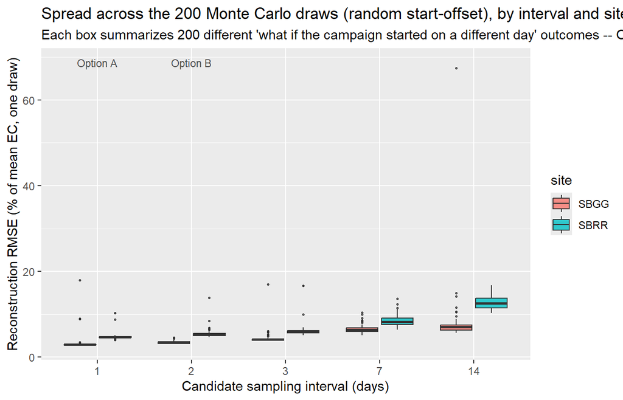

```r
run_mc_raw <- function(site_code) {
  df <- ec %>% filter(site == site_code) %>% arrange(timestamp) %>%
    transmute(time = timestamp, chloride_mgL = sc_25c)
  mc <- monte_carlo_sampling_frequency(df, frequencies_days = c(1, 2, 3, 7, 14), n_draws = 200, seed = 7391)
  mc$site <- site_code
  mc$pct_of_mean <- 100 * mc$rmse / ec_summary$mean_ec[ec_summary$site == site_code]
  mc
}
mc_raw_combined <- bind_rows(run_mc_raw("SBRR"), run_mc_raw("SBGG"))

ggplot(mc_raw_combined, aes(x = factor(frequency_days), y = pct_of_mean, fill = site)) +
  geom_boxplot(outlier.size = 0.6, alpha = 0.8) +
  annotate("text", x = 1, y = max(mc_raw_combined$pct_of_mean) * 1.02, label = "Option A", size = 3, color = "grey30") +
  annotate("text", x = 2, y = max(mc_raw_combined$pct_of_mean) * 1.02, label = "Option B", size = 3, color = "grey30") +
  labs(x = "Candidate sampling interval (days)", y = "Reconstruction RMSE (% of mean EC, one draw)",
       title = "Spread across the 200 Monte Carlo draws (random start-offset), by interval and site",
       subtitle = "Each box summarizes 200 different 'what if the campaign started on a different day' outcomes -- Option A/B marked")
```

## 3 Time of day: does it matter when during the day you sample?

Section 1 already showed a real, modest diurnal EC cycle at both sites. That matters for a grab-sample campaign for a different reason than the day-to-day interval question above: if the sampling time of day drifts from visit to visit, part of the apparent day-to-day change in Cl/EC will really just be a change in what point of the daily cycle was caught, not a real trend. The fix is cheap: sample at a consistent time of day, chosen to sit close to each site’s own 24-hour mean so it is also reasonably representative of “typical” conditions.

```r
ec$hour_bin <- floor(as.numeric(format(ec$timestamp, "%H")) + as.numeric(format(ec$timestamp, "%M")) / 60)
hourly <- ec %>% group_by(site, hour_bin) %>% summarise(mean_ec = mean(sc_25c), .groups = "drop")

hourly_summary <- hourly %>% group_by(site) %>%
  summarise(peak_hour = hour_bin[which.max(mean_ec)], peak_ec = max(mean_ec),
            trough_hour = hour_bin[which.min(mean_ec)], trough_ec = min(mean_ec))
knitr::kable(hourly_summary, digits = 1,
             caption = "Real hourly mean specific conductance: peak and trough clock hour, both sites")
```

Real hourly mean specific conductance: peak and trough clock hour, both sites

| site | peak_hour | peak_ec | trough_hour | trough_ec |
| --- | --- | --- | --- | --- |
| SBGG | 3 | 1105.5 | 21 | 1092.2 |
| SBRR | 9 | 366.0 | 23 | 352.1 |

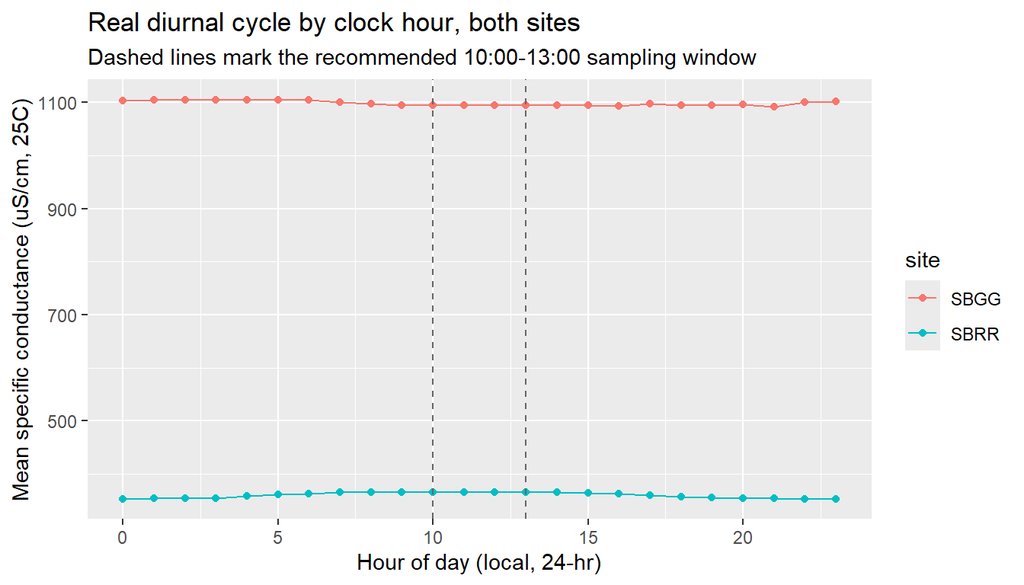

```r
ggplot(hourly, aes(x = hour_bin, y = mean_ec, color = site)) +
  geom_line() + geom_point(size = 1.5) +
  geom_vline(xintercept = c(10, 13), linetype = "dashed", color = "grey40") +
  labs(x = "Hour of day (local, 24-hr)", y = "Mean specific conductance (uS/cm, 25C)",
       title = "Real diurnal cycle by clock hour, both sites",
       subtitle = "Dashed lines mark the recommended 10:00-13:00 sampling window")
```

**Reading**: the two sites are close to *anti-phased* – SBRR peaks around mid-morning to early afternoon (roughly hours 8-14) and troughs overnight, while SBGG peaks overnight and troughs during that same mid-morning-to-afternoon window. There is no single clock hour where both sites sit exactly at their own daily mean simultaneously, but a **late-morning-to-early-afternoon window (about 10:00-13:00 local time)** comes closest for both – SBRR is within its own plateau there, and SBGG’s midday values sit close to (within a few percent of) its overall mean, well inside the day-to-day noise already quantified in Section 1. This window is also the most practical one for a single field day covering both sites (daylight, travel time between Rhodes Road and Geiger Grade, and typical safety/access considerations).

**Recommendation for Tiers 1 and 2 alike**: visit both sites within the same ~10:00-13:00 window on every sampling day, and keep the order and approximate visit time consistent trip to trip (e.g. always SBRR first, then SBGG, or vice versa) so that any residual within-window drift is at least systematic rather than random. This is a small logistical constraint that removes a real, quantifiable source of noise from every downstream Cl-EC comparison.

## 4 Recommendation: a two-tier campaign

**Tier 1 – short, intensive calibration window (2-4 weeks, early field season):** Daily (or, resources permitting, sub-daily/every-other-day) chloride grab samples at both SBRR and SBGG, run concurrently with the already-active conductivity loggers. Purpose: this is the *only* way to finally get enough real, temporally-overlapping Cl-EC pairs to fit a real calibration relationship (Section 3 of `01_conductivity_temporal_structure.qmd`, `03_chloride_models.R`, is already built and waiting for exactly this data) and to directly test whether short-term Cl variability tracks EC’s own real diurnal signal (Section 1/2 above) or behaves differently.

**Isotopes (delta-18O/delta-D) at SBRR and SBGG:** yes, worth including for a subset of Tier 1 visits at *both* sites, not necessarily every single day. SBRR and SBGG are surface-water stream sites, so any real Cl/EC increase observed between them could in principle reflect either real thermal loading along that reach or simple evaporative concentration during transit – Cl and EC alone cannot tell those apart, since both rise under either mechanism. Isotopes can: evaporative concentration shifts delta-18O/delta-D together along a local evaporation line, while conservative thermal mixing does not. Pairing isotope samples with the every-3rd-day cadence in the Tier 1 calendar below (Section 4.1) is enough to test this without isotope costs dominating the whole campaign; see `manuscript/06_calibration_sampling_proposal.qmd` for the broader, project-wide isotope/major-ion rationale.

**Discharge measurement, every visit, both tiers:** every Cl grab sample must be paired with an instantaneous discharge value taken at the same time. Concentration alone cannot support the chloride mass-flux calculation (`scripts/analysis/chloride_mass_balance.R`, the two-station flux formula introduced in Session 39) that this project’s actual thermal-discharge estimates depend on – a Cl-EC calibration without paired Q only ever answers “what is the concentration,” never “how much thermal water is discharging.” **SBRR** is co-located with USGS gauge 10349300, so pairing is just reading the live gauge at sample time (exactly how the real Section 1.1 point was obtained). **SBGG has no permanent gauge**, so a manual discharge measurement (wading-rod current-meter transect, using the `stream_discharge.xlsx` transect template already built into the schema) is a hard requirement at every SBGG visit, not an optional add-on – without it, SBGG can only ever contribute to the Cl-EC concentration calibration, never to a real flux estimate.

**Tier 2 – lower-frequency campaign for the rest of the year (biweekly to monthly):** Once Tier 1 establishes the calibration relationship, routine monitoring can drop to biweekly-or-monthly grab samples with a quantified (not guessed) reconstruction-error cost (Section 2 above) – **plus targeted extra samples bracketing any large storm or spring-runoff event**, since `notebooks/07`/`notebooks/08` already found a real, detectable water-level response to large storms (the Dec-2025 event at STMGID MW10) – the same logic likely applies to Cl/EC at SBRR/SBGG and is worth testing directly with real paired data once Tier 1 samples exist. The same discharge-pairing requirement above continues at Tier 2’s lower frequency – a Cl value without a paired Q still can’t be converted into a real Q_TW estimate, no matter how infrequently it’s collected – and the same 10:00-13:00 sampling window from Section 3 still applies.

**Why not just do one long daily campaign for the whole year?** The Section 2 error curve shows diminishing returns below about a week’s interval once the initial calibration is established – the real payoff of daily sampling is in *establishing the relationship itself* (Tier 1), not in sustaining it indefinitely. A full year of daily sampling would be the most statistically ideal choice but is very unlikely to be logistically realistic for a one-person thesis field campaign; the two-tier design is the pragmatic compromise, explicitly justified rather than assumed.

### 4.1 Timing: should Tier 1 start now, in the fall wet-season transition?

This proposal is being finalized 2026-09-29. A real practical constraint – funding/reporting deadlines favor real Tier 1 data existing before 2027 – pushes toward starting in October or November 2026 rather than waiting for a more hydrologically “ideal” window. That means Tier 1 will likely run during the fall wet-season transition, not the dry summer baseflow period the conductivity record (Section 1) and Monte Carlo results (Section 2) are built from. Worth stating plainly, with real benefits and drawbacks, rather than leaving it implicit.

```r
precip_by_month <- dbGetQuery(con, "
  SELECT strftime('%Y-%m', date) AS year_month,
         SUM(CASE WHEN value > 0 THEN 1 ELSE 0 END) AS wet_days,
         ROUND(SUM(value), 1) AS total_mm
  FROM Weather_Observations
  WHERE parameter = 'PRCP'
  GROUP BY year_month ORDER BY year_month
")
knitr::kable(precip_by_month, col.names = c("Year-month", "Wet days", "Total precip (mm)"),
             caption = "Real NOAA precipitation record at Reno Airport -- the only fall/winter season currently on file")
```

Real NOAA precipitation record at Reno Airport – the only fall/winter season currently on file

| Year-month | Wet days | Total precip (mm) |
| --- | --- | --- |
| 2025-10 | 2 | 0.2 |
| 2025-11 | 8 | 2.2 |
| 2025-12 | 8 | 4.6 |
| 2026-01 | 9 | 11.1 |
| 2026-02 | 12 | 29.2 |
| 2026-03 | 3 | 1.3 |
| 2026-04 | 13 | 3.9 |
| 2026-05 | 7 | 14.5 |
| 2026-06 | 0 | 0.0 |
| 2026-07 | 3 | 10.4 |

**Benefits of running Tier 1 now (fall 2026), even with real storm risk**:

- Meets the real funding/reporting deadline – real Tier 1 data before 2027 is more useful than a scientifically “ideal” campaign that arrives too late to matter for that deadline.
- If a real storm does occur during Tier 1, that is not purely a cost: `notebooks/07`/`notebooks/08` already found a real water-level response to the Dec-2025 storm at STMGID MW10 – a storm captured *during* Tier 1 would be the first real chance to test whether Cl/EC at SBRR/SBGG show an analogous response, a genuinely valuable dataset this project doesn’t have yet.
- Broadens the conductivity record’s seasonal coverage beyond the current July-August-only window (Section 1’s own stated limitation), which matters directly for the diurnal-timing caveat below.

**Drawbacks of running Tier 1 during a precipitation event**:

- A storm mid-campaign introduces a real third end-member (fresh meteoric precipitation) into what Section 1.3’s mixing discussion already treats as a two-end-member (thermal/creek) system – storm-affected Tier 1 samples should be analyzed and flagged separately, not pooled uncritically into the same simple linear Cl-EC fit the rest of Tier 1 is meant to establish.
- Section 3’s 10:00-13:00 sampling-window recommendation was derived from a July-August, solar-heating-driven diurnal cycle – that physical driver is real but weaker in fall (lower sun angle, shorter days) and could be masked entirely on a storm day. The specific clock-hour recommendation should be treated as provisional for a fall campaign, not assumed to transfer directly from the summer record.
- SBGG’s manual current-meter discharge measurement (the paired-discharge requirement above) becomes both more hazardous and less accurate during a real high-turbidity, high-turbulence storm flow – a real field-safety and data-quality consideration, not just an inconvenience.

**Recommendation**: proceed with Tier 1 in fall 2026 given the real funding constraint, but explicitly flag any storm-affected sampling days (directly joinable against this same real `Weather_Observations` PRCP record) as a distinct analysis subset – both a genuine bonus dataset for storm-response testing and a necessary exclusion from the “clean baseflow” calibration fit Tier 1 is primarily designed to produce.

### 4.2 Tier 1 Option A: 14 consecutive days

A concrete, complete 14-consecutive-day version of Tier 1, generated directly (not hand-typed) so it stays consistent with the recommendations above – isotopes on roughly every 3rd visit, discharge paired every visit, both sites within the same time window each day:

```r
tier1_days <- 1:14
tier1_calendar <- data.frame(
  day = tier1_days,
  time_window = "10:00-13:00",
  sites = "SBRR & SBGG",
  cl_major_ions = "Yes (both sites)",
  isotopes_d18O_dD = ifelse(tier1_days %% 3 == 1, "Yes (both sites)", ""),
  discharge_measurement = "SBRR: USGS gauge reading | SBGG: current-meter transect"
)
knitr::kable(tier1_calendar,
             col.names = c("Day", "Time window", "Sites", "Cl + major ions", "Isotopes (d18O/dD)", "Discharge measurement"),
             caption = "Proposed Tier 1 sampling calendar: 14 consecutive days, example start (isotopes on days 1, 4, 7, 10, 13)")
```

Proposed Tier 1 sampling calendar: 14 consecutive days, example start (isotopes on days 1, 4, 7, 10, 13)

| Day | Time window | Sites | Cl + major ions | Isotopes (d18O/dD) | Discharge measurement |
| --- | --- | --- | --- | --- | --- |
| 1 | 10:00-13:00 | SBRR & SBGG | Yes (both sites) | Yes (both sites) | SBRR: USGS gauge reading \| SBGG: current-meter transect |
| 2 | 10:00-13:00 | SBRR & SBGG | Yes (both sites) |  | SBRR: USGS gauge reading \| SBGG: current-meter transect |
| 3 | 10:00-13:00 | SBRR & SBGG | Yes (both sites) |  | SBRR: USGS gauge reading \| SBGG: current-meter transect |
| 4 | 10:00-13:00 | SBRR & SBGG | Yes (both sites) | Yes (both sites) | SBRR: USGS gauge reading \| SBGG: current-meter transect |
| 5 | 10:00-13:00 | SBRR & SBGG | Yes (both sites) |  | SBRR: USGS gauge reading \| SBGG: current-meter transect |
| 6 | 10:00-13:00 | SBRR & SBGG | Yes (both sites) |  | SBRR: USGS gauge reading \| SBGG: current-meter transect |
| 7 | 10:00-13:00 | SBRR & SBGG | Yes (both sites) | Yes (both sites) | SBRR: USGS gauge reading \| SBGG: current-meter transect |
| 8 | 10:00-13:00 | SBRR & SBGG | Yes (both sites) |  | SBRR: USGS gauge reading \| SBGG: current-meter transect |
| 9 | 10:00-13:00 | SBRR & SBGG | Yes (both sites) |  | SBRR: USGS gauge reading \| SBGG: current-meter transect |
| 10 | 10:00-13:00 | SBRR & SBGG | Yes (both sites) | Yes (both sites) | SBRR: USGS gauge reading \| SBGG: current-meter transect |
| 11 | 10:00-13:00 | SBRR & SBGG | Yes (both sites) |  | SBRR: USGS gauge reading \| SBGG: current-meter transect |
| 12 | 10:00-13:00 | SBRR & SBGG | Yes (both sites) |  | SBRR: USGS gauge reading \| SBGG: current-meter transect |
| 13 | 10:00-13:00 | SBRR & SBGG | Yes (both sites) | Yes (both sites) | SBRR: USGS gauge reading \| SBGG: current-meter transect |
| 14 | 10:00-13:00 | SBRR & SBGG | Yes (both sites) |  | SBRR: USGS gauge reading \| SBGG: current-meter transect |

This 14-consecutive-day layout is the tightest, highest-information version of Tier 1. An equally valid variant, if daily field visits aren’t logistically realistic, is the same structure stretched to **every-other-day over 4 weeks** (14 visits total, same isotope/discharge cadence relative to visit number rather than calendar day) – Section 2.1’s spread analysis shows this costs some precision at longer gaps but is far better than jumping straight to Tier 2’s biweekly/monthly cadence without ever establishing the calibration.

### 4.3 Tier 1 Option B: every-other-day over 4 weeks (lower logistical cost)

If committing to 14 *consecutive* days isn’t realistic (competing obligations, no coverage for other fieldwork, etc.), the same 14 visits can instead be spread across a 4-week window, one visit every other day. This is generated the same way as Option A, indexed by visit number rather than calendar day so the isotope/discharge cadence stays identical:

```r
visit_number <- 1:14
tier1b_calendar <- data.frame(
  visit = visit_number,
  calendar_day = 2 * visit_number - 1,
  time_window = "10:00-13:00",
  sites = "SBRR & SBGG",
  cl_major_ions = "Yes (both sites)",
  isotopes_d18O_dD = ifelse(visit_number %% 3 == 1, "Yes (both sites)", ""),
  discharge_measurement = "SBRR: USGS gauge reading | SBGG: current-meter transect"
)
knitr::kable(tier1b_calendar,
             col.names = c("Visit #", "Calendar day (of 28)", "Time window", "Sites",
                           "Cl + major ions", "Isotopes (d18O/dD)", "Discharge measurement"),
             caption = "Tier 1 Option B: every-other-day over 4 weeks (14 visits across 28 calendar days; isotopes on visits 1, 4, 7, 10, 13)")
```

Tier 1 Option B: every-other-day over 4 weeks (14 visits across 28 calendar days; isotopes on visits 1, 4, 7, 10, 13)

| Visit # | Calendar day (of 28) | Time window | Sites | Cl + major ions | Isotopes (d18O/dD) | Discharge measurement |
| --- | --- | --- | --- | --- | --- | --- |
| 1 | 1 | 10:00-13:00 | SBRR & SBGG | Yes (both sites) | Yes (both sites) | SBRR: USGS gauge reading \| SBGG: current-meter transect |
| 2 | 3 | 10:00-13:00 | SBRR & SBGG | Yes (both sites) |  | SBRR: USGS gauge reading \| SBGG: current-meter transect |
| 3 | 5 | 10:00-13:00 | SBRR & SBGG | Yes (both sites) |  | SBRR: USGS gauge reading \| SBGG: current-meter transect |
| 4 | 7 | 10:00-13:00 | SBRR & SBGG | Yes (both sites) | Yes (both sites) | SBRR: USGS gauge reading \| SBGG: current-meter transect |
| 5 | 9 | 10:00-13:00 | SBRR & SBGG | Yes (both sites) |  | SBRR: USGS gauge reading \| SBGG: current-meter transect |
| 6 | 11 | 10:00-13:00 | SBRR & SBGG | Yes (both sites) |  | SBRR: USGS gauge reading \| SBGG: current-meter transect |
| 7 | 13 | 10:00-13:00 | SBRR & SBGG | Yes (both sites) | Yes (both sites) | SBRR: USGS gauge reading \| SBGG: current-meter transect |
| 8 | 15 | 10:00-13:00 | SBRR & SBGG | Yes (both sites) |  | SBRR: USGS gauge reading \| SBGG: current-meter transect |
| 9 | 17 | 10:00-13:00 | SBRR & SBGG | Yes (both sites) |  | SBRR: USGS gauge reading \| SBGG: current-meter transect |
| 10 | 19 | 10:00-13:00 | SBRR & SBGG | Yes (both sites) | Yes (both sites) | SBRR: USGS gauge reading \| SBGG: current-meter transect |
| 11 | 21 | 10:00-13:00 | SBRR & SBGG | Yes (both sites) |  | SBRR: USGS gauge reading \| SBGG: current-meter transect |
| 12 | 23 | 10:00-13:00 | SBRR & SBGG | Yes (both sites) |  | SBRR: USGS gauge reading \| SBGG: current-meter transect |
| 13 | 25 | 10:00-13:00 | SBRR & SBGG | Yes (both sites) | Yes (both sites) | SBRR: USGS gauge reading \| SBGG: current-meter transect |
| 14 | 27 | 10:00-13:00 | SBRR & SBGG | Yes (both sites) |  | SBRR: USGS gauge reading \| SBGG: current-meter transect |

**What this option costs and buys, honestly**: the total real lab cost is *identical* to Option A – same 14 Cl+major-ion analyses, same 5 isotope pairs, same 14 paired discharge measurements – this option only trades calendar time, not lab budget, for reduced field-logistics pressure (no 14-day unbroken commitment). The real statistical cost, stated explicitly rather than left to the graph alone: mean reconstruction error rises from 4.74% to 5.38% at SBRR and from 3.07% to 3.46% at SBGG (Section 2’s marked graph); the worst-case (95th percentile) cost is larger – 5.05% to 6.46% at SBRR, 3.21% to 4.34% at SBGG (Section 2.1’s marked boxplot). Both intervals still sit in the tight, low-error band, well short of weekly’s roughly-doubled error – so an every-other-day cadence is a genuinely reasonable compromise, not a steep step down from daily. If the real limiting factor is a hard budget cap on lab *analyses* rather than field days, neither option reduces cost – that would mean cutting the total visit count itself (e.g. daily for 7 days instead of 14), which would need to be weighed directly against Section 2.1’s real precision-loss curve before recommending it.

### 4.4 Tier 2 sampling timeline (the rest of the year)

Tier 2 was described qualitatively above (biweekly-to-monthly, plus storm-triggered extras); here is a concrete, generated timeline picking up right after either Tier 1 option ends (week 4), transitioning from biweekly to monthly cadence over the rest of the year, with periodic isotope re-checks:

```r
transition_weeks <- seq(5, 11, by = 2)     # biweekly for ~2 months after Tier 1
steady_weeks <- seq(16, 52, by = 4)         # monthly for the remaining ~10 months
tier2_weeks <- c(transition_weeks, steady_weeks)
tier2_phase <- c(rep("Transition (biweekly)", length(transition_weeks)),
                  rep("Steady-state (monthly)", length(steady_weeks)))

tier2_calendar <- data.frame(
  visit = seq_along(tier2_weeks),
  week = tier2_weeks,
  approx_month = ceiling(tier2_weeks / 4.345),
  phase = tier2_phase,
  cl_major_ions = "Yes (both sites)",
  isotopes_d18O_dD = ifelse(seq_along(tier2_weeks) %% 4 == 1, "Yes (quarterly check)", ""),
  discharge_measurement = "SBRR: USGS gauge reading | SBGG: current-meter transect"
)
knitr::kable(tier2_calendar,
             col.names = c("Visit #", "Week (post Tier-1 start)", "Approx. month", "Phase",
                           "Cl + major ions", "Isotopes (d18O/dD)", "Discharge measurement"),
             caption = "Tier 2 timeline: biweekly transition (months 2-3), then monthly (months 4-12), quarterly isotope re-checks")
```

Tier 2 timeline: biweekly transition (months 2-3), then monthly (months 4-12), quarterly isotope re-checks

| Visit # | Week (post Tier-1 start) | Approx. month | Phase | Cl + major ions | Isotopes (d18O/dD) | Discharge measurement |
| --- | --- | --- | --- | --- | --- | --- |
| 1 | 5 | 2 | Transition (biweekly) | Yes (both sites) | Yes (quarterly check) | SBRR: USGS gauge reading \| SBGG: current-meter transect |
| 2 | 7 | 2 | Transition (biweekly) | Yes (both sites) |  | SBRR: USGS gauge reading \| SBGG: current-meter transect |
| 3 | 9 | 3 | Transition (biweekly) | Yes (both sites) |  | SBRR: USGS gauge reading \| SBGG: current-meter transect |
| 4 | 11 | 3 | Transition (biweekly) | Yes (both sites) |  | SBRR: USGS gauge reading \| SBGG: current-meter transect |
| 5 | 16 | 4 | Steady-state (monthly) | Yes (both sites) | Yes (quarterly check) | SBRR: USGS gauge reading \| SBGG: current-meter transect |
| 6 | 20 | 5 | Steady-state (monthly) | Yes (both sites) |  | SBRR: USGS gauge reading \| SBGG: current-meter transect |
| 7 | 24 | 6 | Steady-state (monthly) | Yes (both sites) |  | SBRR: USGS gauge reading \| SBGG: current-meter transect |
| 8 | 28 | 7 | Steady-state (monthly) | Yes (both sites) |  | SBRR: USGS gauge reading \| SBGG: current-meter transect |
| 9 | 32 | 8 | Steady-state (monthly) | Yes (both sites) | Yes (quarterly check) | SBRR: USGS gauge reading \| SBGG: current-meter transect |
| 10 | 36 | 9 | Steady-state (monthly) | Yes (both sites) |  | SBRR: USGS gauge reading \| SBGG: current-meter transect |
| 11 | 40 | 10 | Steady-state (monthly) | Yes (both sites) |  | SBRR: USGS gauge reading \| SBGG: current-meter transect |
| 12 | 44 | 11 | Steady-state (monthly) | Yes (both sites) |  | SBRR: USGS gauge reading \| SBGG: current-meter transect |
| 13 | 48 | 12 | Steady-state (monthly) | Yes (both sites) | Yes (quarterly check) | SBRR: USGS gauge reading \| SBGG: current-meter transect |
| 14 | 52 | 12 | Steady-state (monthly) | Yes (both sites) |  | SBRR: USGS gauge reading \| SBGG: current-meter transect |

**Reading**: this gives 14 routine Tier 2 visits across the year (4 biweekly transition visits, 10 monthly steady-state visits) – combined with Tier 1’s own 14 visits, that’s 28 core Cl+major-ion visits/year, broadly in line with the ~40-total-analyses “Tier 2” target already recommended in `manuscript/06_calibration_sampling_proposal.qmd` once the isotope subset and any storm-triggered extras are added. **This fixed calendar is deliberately a floor, not a ceiling**: per Section 4’s own recommendation, any large storm or spring-runoff event identified in real time should add extra, unscheduled visits bracketing it (before/during/after), the same way `notebooks/07`/`notebooks/08` found a real water-level response to the Dec-2025 storm at STMGID MW10 – those extra visits are not pre-datable and so are intentionally not in the fixed table above.

## 5 What this does and doesn’t tell us yet

- This analysis uses **EC as a stand-in for chloride** because no dense real Cl record exists yet – exactly the gap Tier 1 above is designed to close. Once Tier 1 samples exist, this same Monte Carlo framework should be re-run on the *real* Cl series (via the fitted `03_chloride_models.R` relationship), not just EC, for a final, fully-real recommendation.
- **Neither real ALS lab chemistry nor a paired discharge series currently feeds the Monte Carlo above** – Section 1.1’s single real Cl/discharge pair at SBRR (and SBGG’s complete absence of one) is shown for context only; it predates the conductivity record by ~2.5 months and is nowhere near enough (n=1, zero overlap) to validate or calibrate anything. Discharge pairing at every Tier 1/2 visit (Section 4) is what will finally make a real flux-based version of this Monte Carlo possible.
- The ~5-week record used here (mid-July to late-August 2026) does not yet span a full season – the daily-range/diurnal-amplitude numbers above may not hold in winter/spring; this is itself a reason to keep sampling through Tier 2 rather than assuming summer behavior generalizes.
- This document is deliberately reproducible (a live notebook, not a static writeup) so it can be re-run and refined as real Tier 1 data starts arriving.